# Problem Set 7

Rebecca Xi

4/8/2020

## Question 1: Conduct exploratory data analysis

### 1A) Summary Statistics

Data summary

| Name | sen_rep_116$nominate_perc… |
| --- | --- |
| Number of rows | 537 |
| Number of columns | 1 |
| _______________________ |  |
| Column type frequency: |  |
| numeric | 1 |
| ________________________ |  |
| Group variables | None |

**Variable type: numeric**

Data summary

| skim_variable | n_missing | complete_rate | mean | sd | p0 | p25 | p50 | p75 | p100 | hist |
| --- | --- | --- | --- | --- | --- | --- | --- | --- | --- | --- |
| data | 0 | 1 | 49.95 | 28.95 | 0 | 24.81 | 50 | 75 | 100 | ▇▇▇▇▇ |

| Name | sen_rep_116$age |
| --- | --- |
| Number of rows | 537 |
| Number of columns | 1 |
| _______________________ |  |
| Column type frequency: |  |
| numeric | 1 |
| ________________________ |  |
| Group variables | None |

**Variable type: numeric**

| skim_variable | n_missing | complete_rate | mean | sd | p0 | p25 | p50 | p75 | p100 | hist |
| --- | --- | --- | --- | --- | --- | --- | --- | --- | --- | --- |
| data | 0 | 1 | 58.91 | 11.78 | 30 | 50 | 59 | 68 | 86 | ▂▅▇▇▂ |

### 1B) Visualizing a single variable

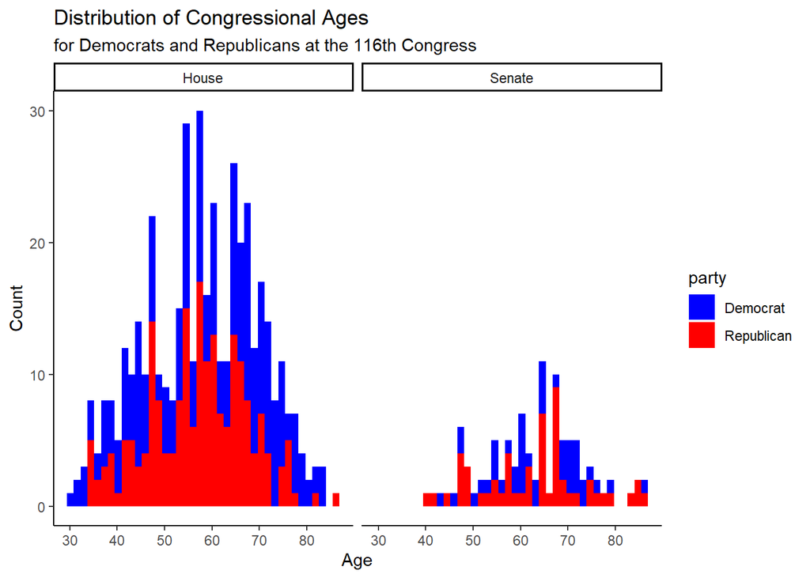

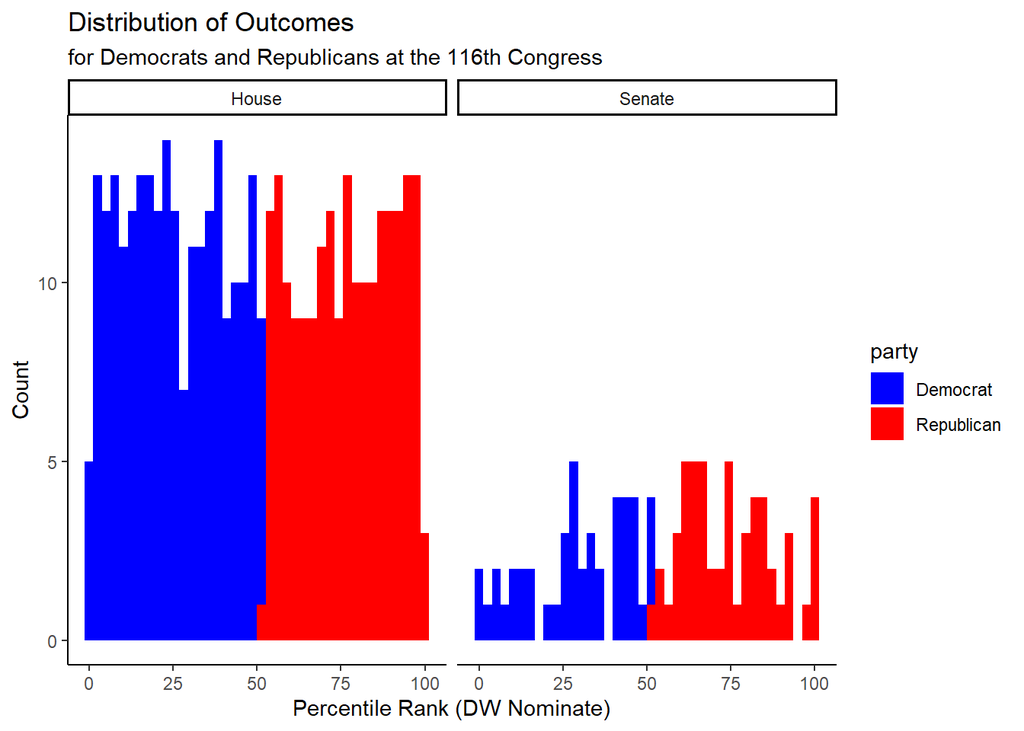

### 1C) Bivariate Correlations

```
##         corr
## 1 -0.1593432
```

A negative correlation coefficient indicates a negative relationship (if one variable increases, the value of the other decreases), while a positive coefficient indicates a positive relationship (the values of both variables move in the same direction).

### 1D) Plotting Bivariate relationships

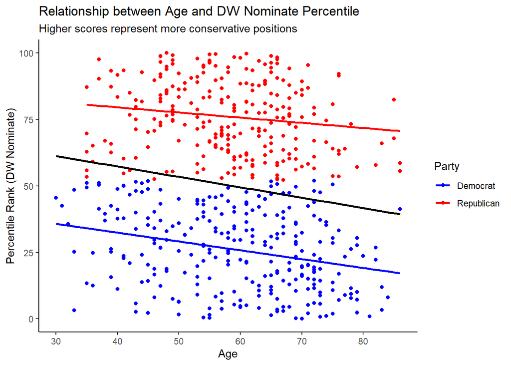

## Question 2: Run a single regression

### 2A) Using lm()

Effect of Age on DW Nominate Percentile

Higher percentile suggests more conservative

| Variable | Estimate | Lower bound | Upper bound |
| --- | --- | --- | --- |
| (Intercept) | 45.7469111 | 37.4458230 | 54.0479993 |
| age | -0.3322965 | -0.4687675 | -0.1958254 |

### 2B) Interpreting results

The slope coefficient on age of -0.33 indicates that the average treatment effect of increasing the age of a democratic member of Congress by 1 year is -0.33. This means that aging one year has the effect, on a democratic member of Congress, of decreasing that member’s percentile rank for DW nominate scores by about 0.33 percentiles. We should beware of interpreting the estimated correlation as causal right away. There may be other reasons or even *confounding variables* that affect the relationship between age and level of conservatism. One such reason may be that a subset of the older democratic members of the 116th Congress were influenced by a common, more liberal political ideology, perhaps even in their youth, and that democratic ideology has become relatively less liberal since.

We calculate a confidence interval around the average treatment effect to reflect the uncertainty that comes with estimation. Since the slope coefficient in the linear regression is measured with some uncertainty, the estimate of potential DW Nominate percentile outcome under the “treatment” of age is also measured with some uncertainty, and we need to take that into consideration.

### 2C) Regression and the Rubin Causal Model

The coefficient on military is equivalent to the average treatment effect (of undergoing active military duty) on DW Nominate percentile rankings. It serves as a way to quantify the difference in potential outcomes, between the potential outcome when a member does not undergo military duty and the potential outcome when a member does go into the military. Randomization is necessary to support this interpretation as causal: random assignment is the best way to infer an average treatment effect, given a large enough sample size.

## Question 3: Generalize to many regressions

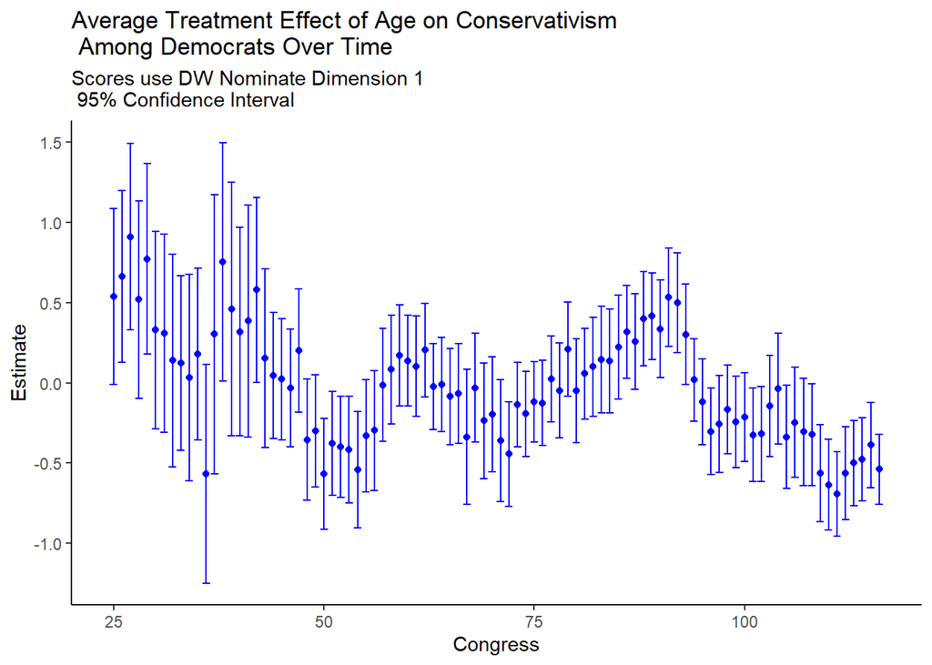